# EDAV PSet 2

Zihao Liu and George Reynolds

Read *Graphical Data Analysis with R*, Ch. 4, 5

Grading is based both on your graphs and verbal explanations. Follow all best practices as discussed in class.

### 1. Jungle Garden

Data: `garden_planting` from **gardenR** package

```
# install.packages("remotes")
# remotes::install_github("llendway/gardenR")
```

For each of the following choose the appropriate data from the package and draw a bar chart, following best practices, that can directly answer the following questions. For each, explain your choice of bar order.

1. How many varieties of each type of vegetable were planted?

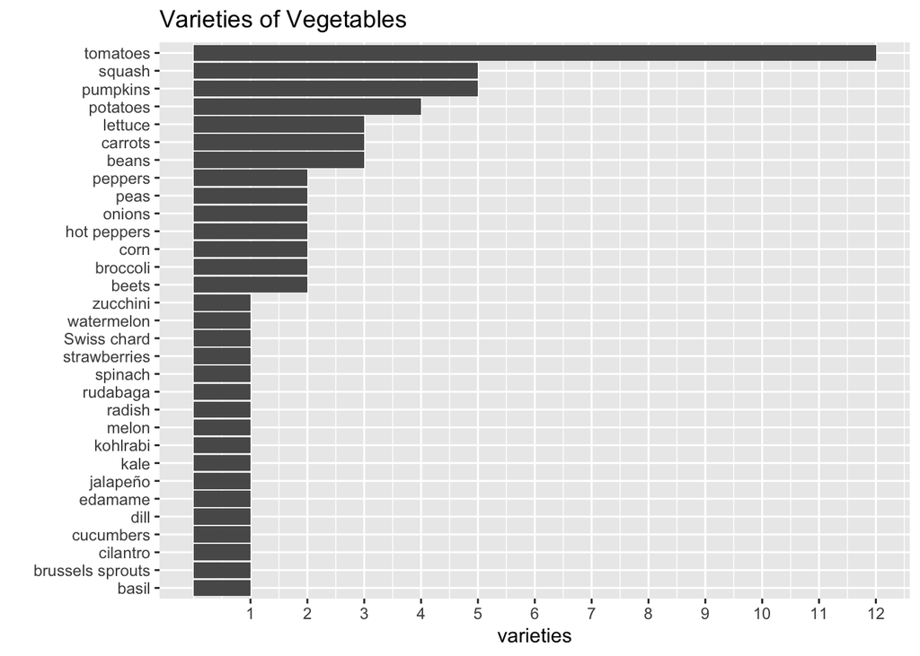

```r
by_veg <- group_by(garden_planting, vegetable)
by_veg_var <- summarise(by_veg, varieties = n_distinct(variety))

ggplot(by_veg_var, aes(varieties, fct_reorder(`vegetable`, varieties))) +
  geom_bar(stat = "identity") +
  scale_x_continuous(breaks = seq(1, 13, 1)) +
  ggtitle("Varieties of Vegetables") + ylab("")
```

2. Were there any days of the week that Dr. Lendway never planted? Which days of the week was she most likely to be found planting? (Measure by the number of rows in `garden_planting`.)

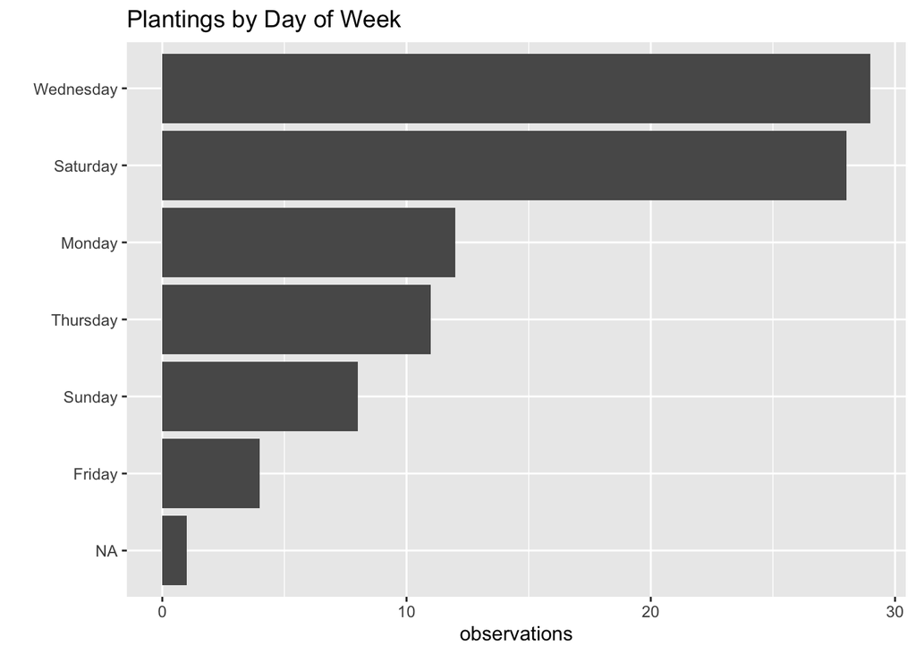

```r
gp <- garden_planting
gp$dayofweek <- weekdays(as.Date(gp$date))

by_day <- group_by(gp, dayofweek)

by_day_freq <- by_day %>% count()
names(by_day_freq)[names(by_day_freq) == "n"] <- "observations"

by_day_freq %>% mutate(dayofweek=fct_explicit_na(dayofweek,"NA"))%>%
ggplot( aes(x = observations, y = fct_reorder(`dayofweek`, observations))) +
  geom_bar(stat = "identity") +
  ggtitle("Plantings by Day of Week") + ylab("")
```

Dr. Lendway was most likely to plant on Wednesdays and Saturdays. It seems that Dr. Lendway never planted on a Tuesday; however, it must be noted that there was one observation with no date recorded. It is possible that this NA value was in fact a Tuesday. Otherwise, this was never a planting day.

3. How many seeds were planted in each plot?

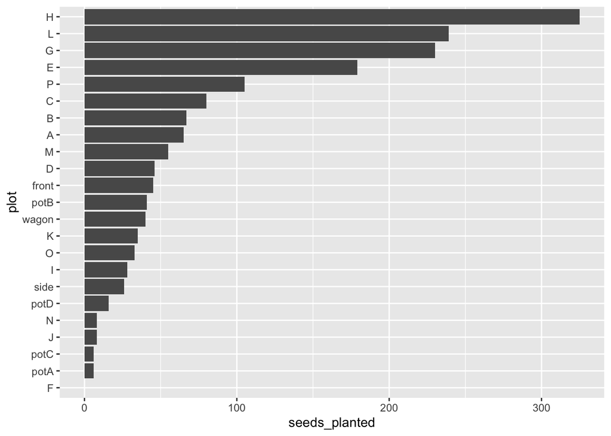

```r
gp %>%
  group_by(plot) %>%
  summarise(seeds_planted = sum(number_seeds_planted, na.rm = T))  %>%
  arrange(seeds_planted) %>%
  mutate(plot=fct_reorder(plot,seeds_planted))%>%
    ggplot(aes(x=plot,y=seeds_planted))+
         geom_col()+
         coord_flip()+
       theme_grey()
```

I sort plots in descending order according to the numbers of seeds in.

### 2. Vaccination Rates

To get the data for this problem, we’ll scrape data from this page: https://www.beckershospitalreview.com/public-health/states-ranked-by-percentage-of-covid-19-vaccines-administered.html. Important: you should only execute parts (a) and (b) once. After running these lines, comment them out, and leave them commented out in the submitted version.

1. Check that it’s ok to scrape the site. What is the result?

```r
# robotstxt::paths_allowed("https://www.beckershospitalreview.com/public-health/states-ranked-by-percentage-of-covid-19-vaccines-administered.html")
```

The check on the url returned “TRUE”.

2. Read the page at the URL listed above and save it.

```r
# vaxes <- "https://www.beckershospitalreview.com/public-health/states-ranked-by-percentage-of-covid-19-vaccines-administered.html"
# vaxes <- read_html(vaxes)
vaxes <- read_html("vaccines.html")
```

3. Read in the page saved in part b) and create a data frame with the following columns: `State`, `Distributed`, `Administered`, `Percentage`. Display the first six rows of the data frame.

```r
list_items <- vaxes %>%
  html_node("body") %>%
  html_nodes("#content") %>%
  html_nodes("#left-column") %>%
  html_nodes(".full-article-wrapper") %>%
  html_nodes("ol") %>%
  html_nodes("li")

df <- data.frame(State = character(),
                 Distributed = character(),
                 Administered = character(),
                 Percentage = double())

state_name <- function(state) {
  state_name <- word(list_items[[state]] %>% html_text()
                   , sep = "\\Doses")
  state_name <- str_remove(state_name, "\n")
  return(state_name)}

distributed <- function(state){
  distributed <- word(
    word(list_items[[state]] %>% html_text(), 2,
         sep = "\\Doses"),
    5)
  return(distributed)
}

administered <- function(state){
  administered <- trimws(sapply(str_split(word(word(list_items[[state]] %>% html_text(), 3, sep = "\\:"), sep = "\\of"), "P"), `[`,1))

  return(administered)
}

for (state in 1:50){
  df[nrow(df) + 1,] <- c(state_name(state)
                    , distributed(state)
                    , administered(state)
                    , 0 )}

df$Distributed <- as.numeric(gsub(",", "", df$Distributed))
df$Administered <- as.numeric(gsub(",", "", df$Administered))
df$Percentage <- df$Administered/df$Distributed

head(df)
```

```
##            State Distributed Administered Percentage
## 1   North Dakota      131625       126822  0.9635100
## 2     New Mexico      364875       331793  0.9093333
## 3  West Virginia      357000       322046  0.9020896
## 4        Montana      163675       137765  0.8416985
## 5 South Carolina      684700       568917  0.8308997
## 6   South Dakota      161150       131439  0.8156314
```

4. Create a Cleveland dot plot showing the percentage of distributed vaccines that have been administered.

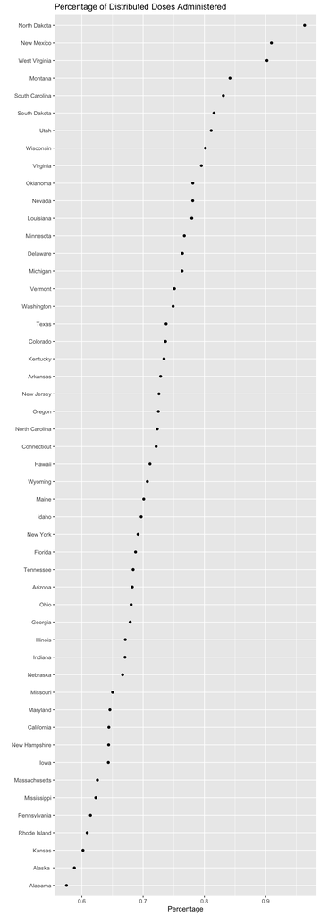

```r
ggplot(df, aes(Percentage, fct_reorder(`State`, Percentage))) +
  geom_point() +
  ggtitle("Percentage of Distributed Doses Administered") + ylab("")
```

5. Create a multiple Cleveland dot plot showing doses distributed in one color and doses administered in another for each state. Experiment with different sorting orders. Choose the one that you think works best and explain why.

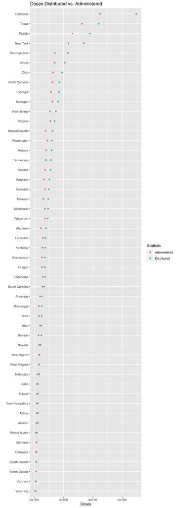

```r
ggplot(df, aes(Distributed, fct_reorder(`State`, Distributed), colour = "Distributed")) +
  geom_point() +
  geom_point(aes(x = Administered, y = State, colour = "Administered")) +
    scale_colour_discrete(name = "Statistic") +
  ggtitle("Doses Distributed vs. Administered") +
  ylab("") + xlab("Doses")
```

### 3. Taxis

Data: NYC yellow cab rides in June 2020, available here:

https://www1.nyc.gov/site/tlc/about/tlc-trip-record-data.page

It’s a large file so you may work with a reasonably-sized random sample of the data (for example 10000 rows). If you remove outliers / impossibilities explain your logic.

Draw four plots of `tip_amount` vs. `fare_amount` with the following variations:

1. Scatterplot with alpha blending

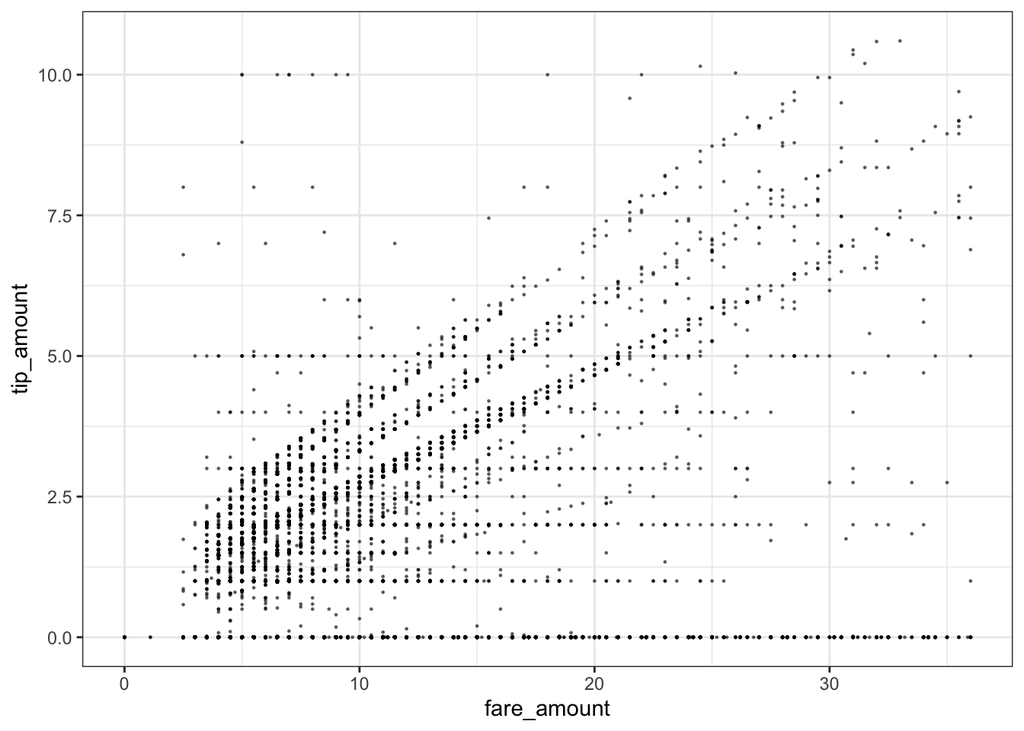

```r
data3 <- read_csv("yellow_tripdata_2020-06.csv") %>% na.omit()
set.seed(1234)
data3_1 <- data3[sample(1:nrow(data3), 10000), ]

data3_a <- data3_1 %>%
filter(between(fare_amount, 0, quantile(fare_amount, 0.75)+3*IQR(fare_amount)) &
between(tip_amount, 0,  quantile(tip_amount, 0.75)+3*IQR(tip_amount)))

ggplot(data3_a, aes(fare_amount, tip_amount)) +
  geom_point(alpha = 0.5, size = 0.2) +
  theme_bw()
```

By observing raw data, we can find some features like fare_amount and tip_amount have a very large range of values. There are many ways to locate the outliers in a dataset. I choose to use interquartile range to select the outliers. An outlier would be a point below [Q1- (1.5)IQR] or above [Q3+(1.5)IQR] while values above [Q3 + 3xIQR] or below [Q1 - 3xIQR] are considered as extreme points. In that, Q1= 25th percentile, Q3= 75th percentile and IQR= Q3 – Q1. I tried both of them and found the former will remove so many points. So I choose to set the coefficient of IQR as 3 to make more values available for us and remove some extreme outliers at the same time. In that case, I observed that the lower bound, is negative which doesn’t match the reality. Therefore I modified the lower bound to zero to make it more reasonable.

2. Scatterplot with alpha blending + density estimate contour lines

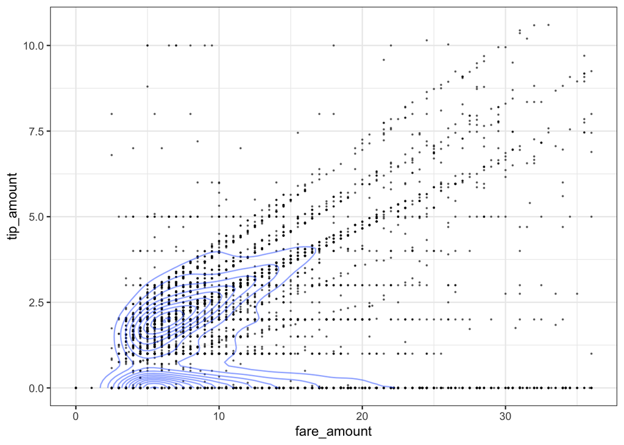

```r
ggplot(data3_a, aes(fare_amount, tip_amount)) +
  geom_point(alpha = 0.5,size = 0.2) +
  theme_bw() +
  geom_density_2d(alpha = 0.5)
```

3. Hexagonal heatmap of bin counts

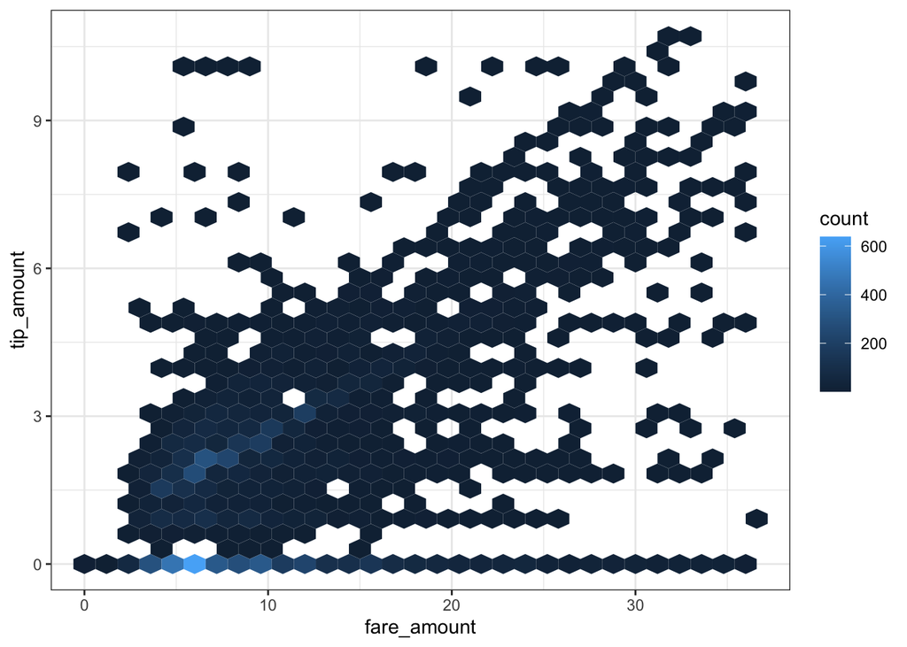

```r
ggplot(data3_a, aes(fare_amount, tip_amount)) +
  geom_hex(bins=30) +
  theme_bw()
```

4. Square heatmap of bin counts

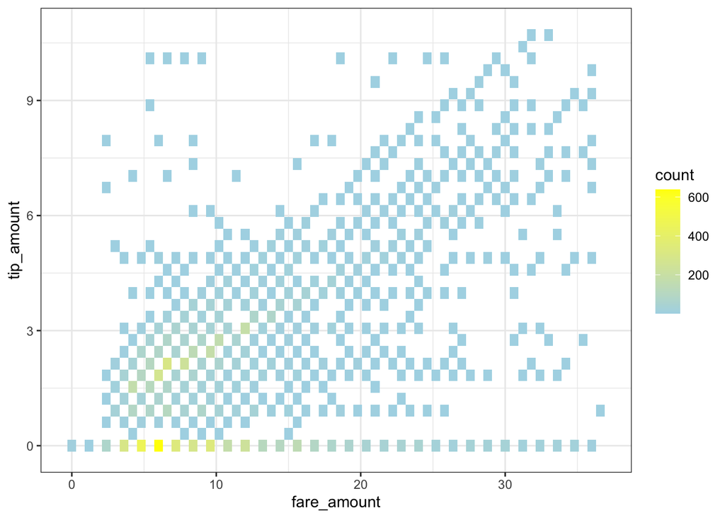

```r
ggplot(data3_a, aes(fare_amount, tip_amount)) +
  geom_tile(stat = "binhex") +
  scale_fill_gradient(low="lightblue", high="yellow") +
  theme_bw()
```

For all, adjust parameters to the levels that provide the best views of the data.

5. Describe noteworthy features of the data, using the “Movie ratings” example on page 82 (last page of Section 5.3) as a guide.

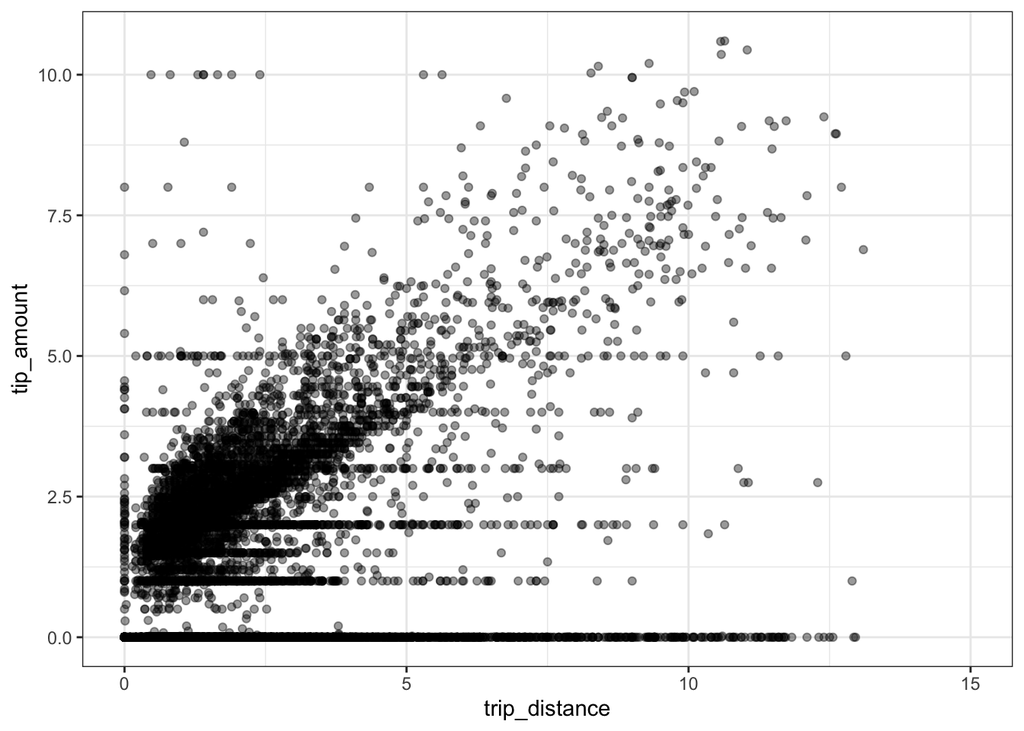

```r
ggplot(data3_a, aes(trip_distance,tip_amount )) +
  geom_point(alpha=0.4) +
  xlim(0,15)+
  theme_bw()
```

From the plot, we can get some sights:

(1)Tips are proportional to distance and tips generally increase as distance increases.

(3)Most tips are more than 1 dollar.

(4)When distance increases, people are more likely to tip in round figure.

(5)Most tips are concentrated in the interval of [1,5].